# Project of Statistical Learning

Salvatore Mancino B34000061

11/07/2022

# Multiple Linear Regression

## Data set

For this part of the project I will consider the **Pima Indians Diabetes Database**.

This data set contains 9 variables measured on 392 women of the Pima Indians heritage. The 9 variables are:

- **pregnant:** Number of times pregnant
- **glucose:** Plasma glucose concentration (glucose tolerance test)
- **pressure:** Diastolic blood pressure (mm Hg)
- **triceps:** Triceps skin fold thickness (mm)
- **insulin:** 2-Hour serum insulin (mu U/ml)
- **mass:** Body mass index (weight in kg/(height in m)^2)
- **pedigree:** Diabetes pedigree function
- **age:** Age (years)
- **diabetes:** Class variable (test for diabetes)

The aim of this part of the project is to see which variables affect the level of glucose of the patients.First of all, let’s explore the data set by providing a summary of the variables:

```r
PimaIndiansDiabetes2 <- read_excel("PimaIndiansDiabetes2.xlsx")
PimaIndiansDiabetes2 <- PimaIndiansDiabetes2 %>%
  mutate(diabetes = ifelse(diabetes=="pos",1,0))
PimaIndiansDiabetes2$diabetes <- as.factor(PimaIndiansDiabetes2$diabetes)
rownames(PimaIndiansDiabetes2)=c(1:nrow(PimaIndiansDiabetes2))
print(dfSummary(PimaIndiansDiabetes2,
                varnumbers =  FALSE,
                valid.col = FALSE,
                graph.magnif = 0.75),
      method = 'render')
```

Data Frame Summary

PimaIndiansDiabetes2

**Dimensions**: 392 x 9  
**Duplicates**: 8

| **Variable** | **Stats / Values** | **Freqs (% of Valid)** | **Graph** | **Missing** |
| --- | --- | --- | --- | --- |
| pregnant [numeric] | Mean (sd) : 3.3 (3.2) min ≤ med ≤ max: 0 ≤ 2 ≤ 17 IQR (CV) : 4 (1) | 17 distinct values |  | 0 (0.0%) |
| glucose [numeric] | Mean (sd) : 122.8 (30) min ≤ med ≤ max: 68 ≤ 119.5 ≤ 198 IQR (CV) : 44.2 (0.2) | 116 distinct values |  | 0 (0.0%) |
| pressure [numeric] | Mean (sd) : 70.9 (12.4) min ≤ med ≤ max: 24 ≤ 70 ≤ 110 IQR (CV) : 16 (0.2) | 36 distinct values |  | 0 (0.0%) |
| triceps [numeric] | Mean (sd) : 29 (10.3) min ≤ med ≤ max: 7 ≤ 29 ≤ 60 IQR (CV) : 15 (0.4) | 47 distinct values |  | 0 (0.0%) |
| insulin [numeric] | Mean (sd) : 155.2 (113.8) min ≤ med ≤ max: 16 ≤ 126 ≤ 846 IQR (CV) : 113.2 (0.7) | 180 distinct values |  | 0 (0.0%) |
| mass [numeric] | Mean (sd) : 33.1 (6.8) min ≤ med ≤ max: 18.2 ≤ 33.2 ≤ 67.1 IQR (CV) : 8.4 (0.2) | 189 distinct values |  | 0 (0.0%) |
| pedigree [numeric] | Mean (sd) : 0.5 (0.3) min ≤ med ≤ max: 0.1 ≤ 0.4 ≤ 1.7 IQR (CV) : 0.4 (0.6) | 324 distinct values |  | 0 (0.0%) |
| age [numeric] | Mean (sd) : 31 (10.2) min ≤ med ≤ max: 21 ≤ 27 ≤ 81 IQR (CV) : 14 (0.3) | 43 distinct values |  | 0 (0.0%) |
| diabetes [factor] | 1. 0 2. 1 | 263 ( 67.1% ) 129 ( 32.9% ) |  | 0 (0.0%) |

Generated by summarytools 1.0.0 ([R](https://www.r-project.org/) version 4.1.1)  
2022-07-07

## Model 1

I start by considering the full model:

```r
mod1=lm(glucose ~.,PimaIndiansDiabetes2)
summary(mod1)
```

```
##
## Call:
## lm(formula = glucose ~ ., data = PimaIndiansDiabetes2)
##
## Residuals:
##     Min      1Q  Median      3Q     Max
## -74.183 -14.132  -2.912  13.207  76.481
##
## Coefficients:
##             Estimate Std. Error t value Pr(>|t|)
## (Intercept) 83.54753    8.08811  10.330  < 2e-16 ***
## pregnant    -0.14206    0.47459  -0.299   0.7648
## pressure     0.15993    0.09880   1.619   0.1063
## triceps      0.03648    0.14475   0.252   0.8012
## insulin      0.11958    0.01057  11.316  < 2e-16 ***
## mass        -0.22718    0.22770  -0.998   0.3190
## pedigree    -5.01037    3.83545  -1.306   0.1922
## age          0.38317    0.15866   2.415   0.0162 *
## diabetes1   21.03343    2.68772   7.826 4.98e-14 ***
## ---
## Signif. codes:  0 '***' 0.001 '**' 0.01 '*' 0.05 '.' 0.1 ' ' 1
##
## Residual standard error: 21.91 on 383 degrees of freedom
## Multiple R-squared:  0.4763, Adjusted R-squared:  0.4654
## F-statistic: 43.55 on 8 and 383 DF,  p-value: < 2.2e-16
```

At the 5% significance level not all the variables are significant in predicting the level of glucose of the patients, so I’ve iteratively removed the least contributive predictors and I’ve obtained the following model:

```r
mod2=lm(glucose ~ insulin + age + diabetes,PimaIndiansDiabetes2)
summary(mod2)
```

```
##
## Call:
## lm(formula = glucose ~ insulin + age + diabetes, data = PimaIndiansDiabetes2)
##
## Residuals:
##     Min      1Q  Median      3Q     Max
## -73.476 -13.800  -2.209  13.072  76.641
##
## Coefficients:
##             Estimate Std. Error t value Pr(>|t|)
## (Intercept) 85.10979    3.66817  23.202  < 2e-16 ***
## insulin      0.11791    0.01033  11.410  < 2e-16 ***
## age          0.40943    0.11643   3.517 0.000489 ***
## diabetes1   20.33079    2.59258   7.842 4.34e-14 ***
## ---
## Signif. codes:  0 '***' 0.001 '**' 0.01 '*' 0.05 '.' 0.1 ' ' 1
##
## Residual standard error: 21.92 on 388 degrees of freedom
## Multiple R-squared:  0.4693, Adjusted R-squared:  0.4652
## F-statistic: 114.3 on 3 and 388 DF,  p-value: < 2.2e-16
```

Now all the variables included in the model are significant at the 5% level of significance.

### Assumptions model 1

I have to check if the classical 7 assumptions of the multiple linear regression are satisfied, otherwise the model is not valid.

#### 1) The regression model is linear in parameters

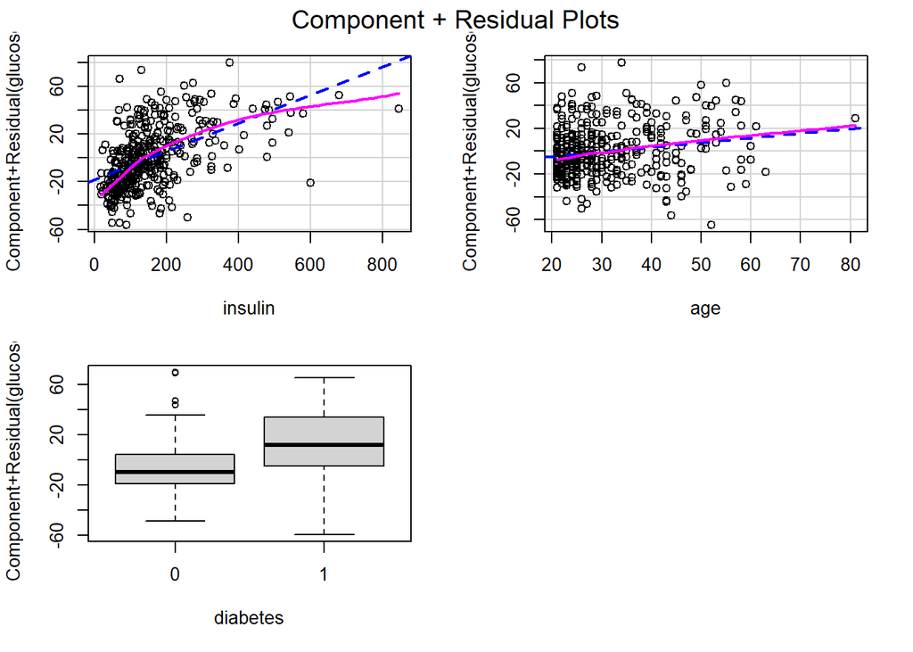

```r
par(mfrow=c(4,3))
car::crPlots(mod2)
```

There is a linearity problem because the violet line that models the residuals of the predictor insulin against the dependent variable glucose is not linear as the blue line.

## Model 2

Let’s try another model:

```r
mod3=lm(glucose ~ poly(insulin,3) + age + diabetes,PimaIndiansDiabetes2)
summary(mod3)
```

```
##
## Call:
## lm(formula = glucose ~ poly(insulin, 3) + age + diabetes, data = PimaIndiansDiabetes2)
##
## Residuals:
##     Min      1Q  Median      3Q     Max
## -66.488 -13.214  -2.002  11.116  79.301
##
## Coefficients:
##                    Estimate Std. Error t value Pr(>|t|)
## (Intercept)        105.7252     3.5494  29.786  < 2e-16 ***
## poly(insulin, 3)1  274.0342    22.4927  12.183  < 2e-16 ***
## poly(insulin, 3)2 -111.0138    21.4094  -5.185 3.49e-07 ***
## poly(insulin, 3)3   46.7172    21.4967   2.173   0.0304 *
## age                  0.3583     0.1134   3.161   0.0017 **
## diabetes1           18.1060     2.5326   7.149 4.40e-12 ***
## ---
## Signif. codes:  0 '***' 0.001 '**' 0.01 '*' 0.05 '.' 0.1 ' ' 1
##
## Residual standard error: 21.14 on 386 degrees of freedom
## Multiple R-squared:  0.5088, Adjusted R-squared:  0.5025
## F-statistic: 79.98 on 5 and 386 DF,  p-value: < 2.2e-16
```

In this model. the relationship between insulin and glucose is modeled as a 3rd degree polynomial.

### Assumptions model 2

Let’s check again if the assumptions are satisfied.

#### 1) The regression model is linear in parameters

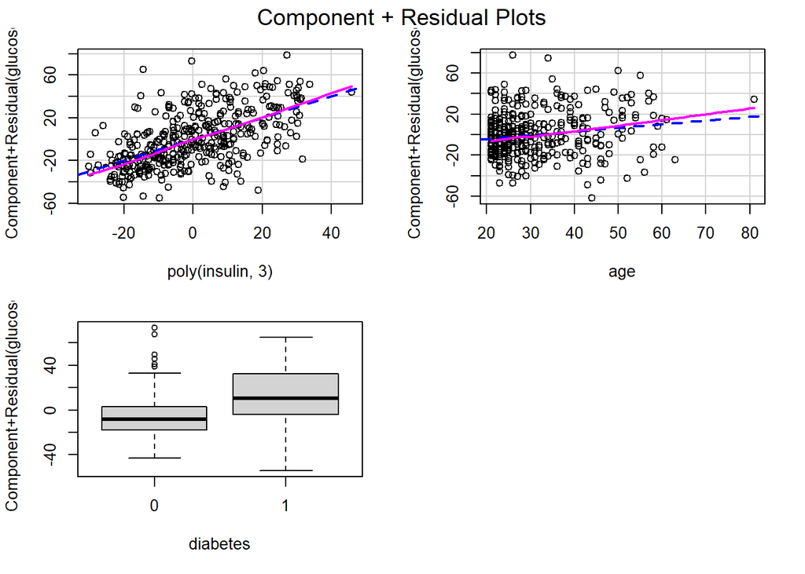

```r
par(mfrow=c(4,3))
car::crPlots(mod3)
```

The linearity assumption is now satisfied.

#### 2) The mean of residuals is zero and the residuals are normally distributed

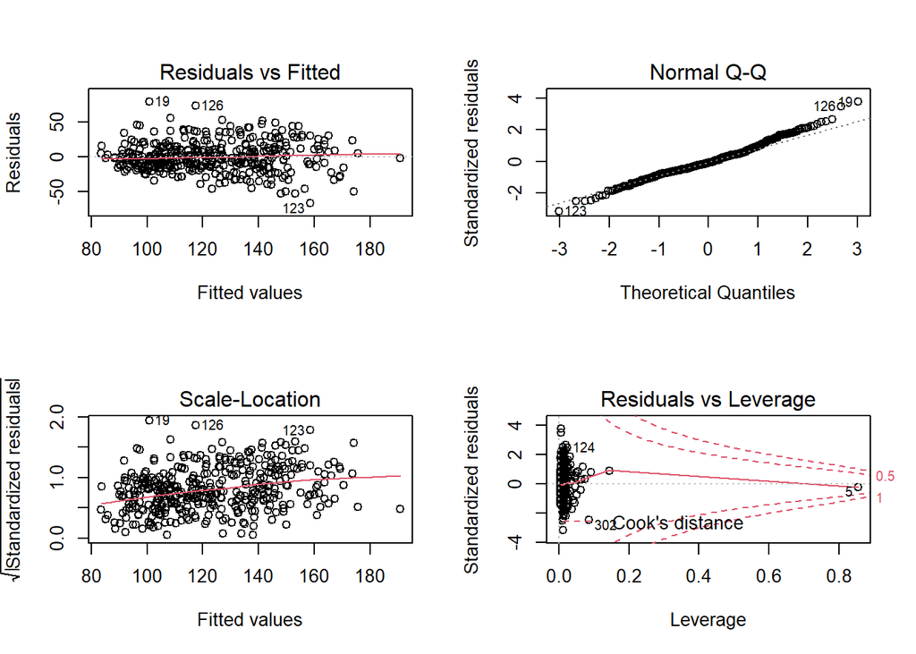

```r
par(mfrow = c(2, 2))
plot(mod3)
```

```r
mean(mod3$residuals)
```

```
## [1] -3.564348e-16
```

The mean of the residuals is numerically zero.

```r
library(tseries)
shapiro.test(mod3$residuals)
```

```
##
##  Shapiro-Wilk normality test
##
## data:  mod3$residuals
## W = 0.98791, p-value = 0.002435
```

The residuals are not normally distributed. I have to make some other changes.

## Final Model

The final model is the following:

$$log(glucose) = B_0 + B_1insulin + B_2insulin^2 + B3insulin^3 + B_4age + B_5diabetes + \epsilon$$

It was obtained by removing some outliers and using the logarithm of the dependent variable.

```r
library(jtools)
library(tseries)
library(lmtest)
new_PimaIndiansDiabetes2 <- PimaIndiansDiabetes2[-c(5,19,123,226),]
mod4=lm(log(glucose) ~ poly(insulin,3) + age + diabetes,new_PimaIndiansDiabetes2)
summary(mod4)
```

```
##
## Call:
## lm(formula = log(glucose) ~ poly(insulin, 3) + age + diabetes,
##     data = new_PimaIndiansDiabetes2)
##
## Residuals:
##      Min       1Q   Median       3Q      Max
## -0.43934 -0.10557 -0.00375  0.10140  0.50167
##
## Coefficients:
##                     Estimate Std. Error t value Pr(>|t|)
## (Intercept)        4.6454658  0.0275279 168.755  < 2e-16 ***
## poly(insulin, 3)1  2.2755099  0.1729542  13.157  < 2e-16 ***
## poly(insulin, 3)2 -1.0834488  0.1675089  -6.468 3.04e-10 ***
## poly(insulin, 3)3  0.3693085  0.1645082   2.245   0.0253 *
## age                0.0028954  0.0008805   3.288   0.0011 **
## diabetes1          0.1373684  0.0196652   6.985 1.27e-11 ***
## ---
## Signif. codes:  0 '***' 0.001 '**' 0.01 '*' 0.05 '.' 0.1 ' ' 1
##
## Residual standard error: 0.1639 on 382 degrees of freedom
## Multiple R-squared:  0.5372, Adjusted R-squared:  0.5311
## F-statistic: 88.67 on 5 and 382 DF,  p-value: < 2.2e-16
```

All the regressor coefficients are significant at the 5% level of significance. Before checking the assumptions let’s comment the results:

- The relationship between insulin and glucose is not linear, but is modeled as a 3rd degree polynomial;
- On average, holding all the other variables constant, for a one-year increase of the age glucose increases by 0.29%;
- On average, the level of glucose is 100(e^0.14 - 1) = 15% higher in patients who have diabetes than in patients without diabetes.

Moreover, the model is able to capture the 54% of the variability of the phenomenon.

### Assumptions final model

Let’s check the assumptions of this model.

#### 1) The regression model is linear in parameters

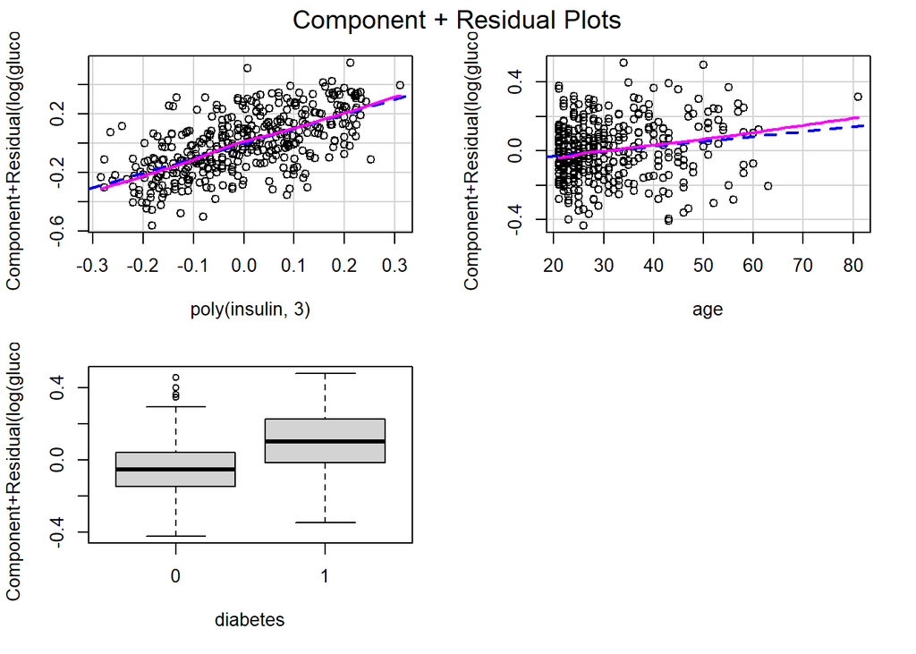

```r
par(mfrow=c(4,3))
car::crPlots(mod4)
```

The linearity assumption is satisfied.

#### 2) The mean of residuals is zero and the residuals are normally distributed

```r
mean(mod4$residuals)
```

```
## [1] 2.589249e-18
```

The mean of the residuals is numerically 0.

```r
shapiro.test(mod4$residuals)
```

```
##
##  Shapiro-Wilk normality test
##
## data:  mod4$residuals
## W = 0.99823, p-value = 0.9615
```

The residuals are normally distributed so the assumption is satisfied.

#### 3) Homoscedasticity of residuals

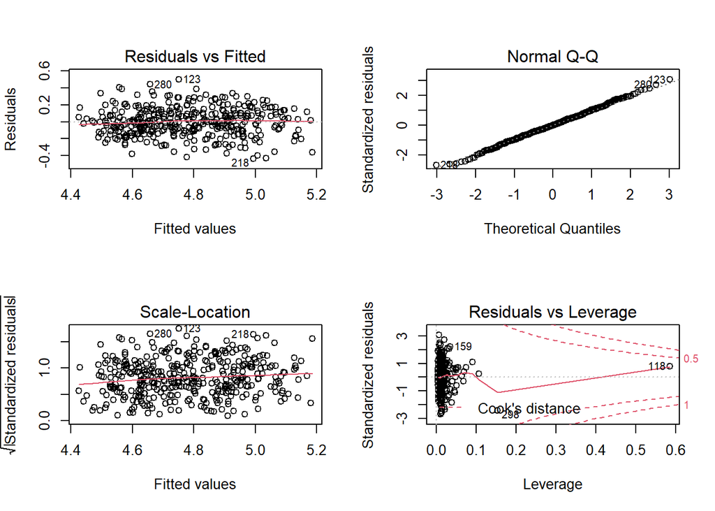

```r
par(mfrow = c(2, 2))
plot(mod4)
```

According to the scale-location plot, residuals seem to be homoscedastic, but let’s conduct a statistical test.

```r
library(skedastic)
gqtest(mod4)
```

```
##
##  Goldfeld-Quandt test
##
## data:  mod4
## GQ = 1.1908, df1 = 188, df2 = 188, p-value = 0.1161
## alternative hypothesis: variance increases from segment 1 to 2
```

According to the Goldfel-Quandt test the homoscedasticity assumption is satisfied.

#### 4) No autocorrelation of residuals

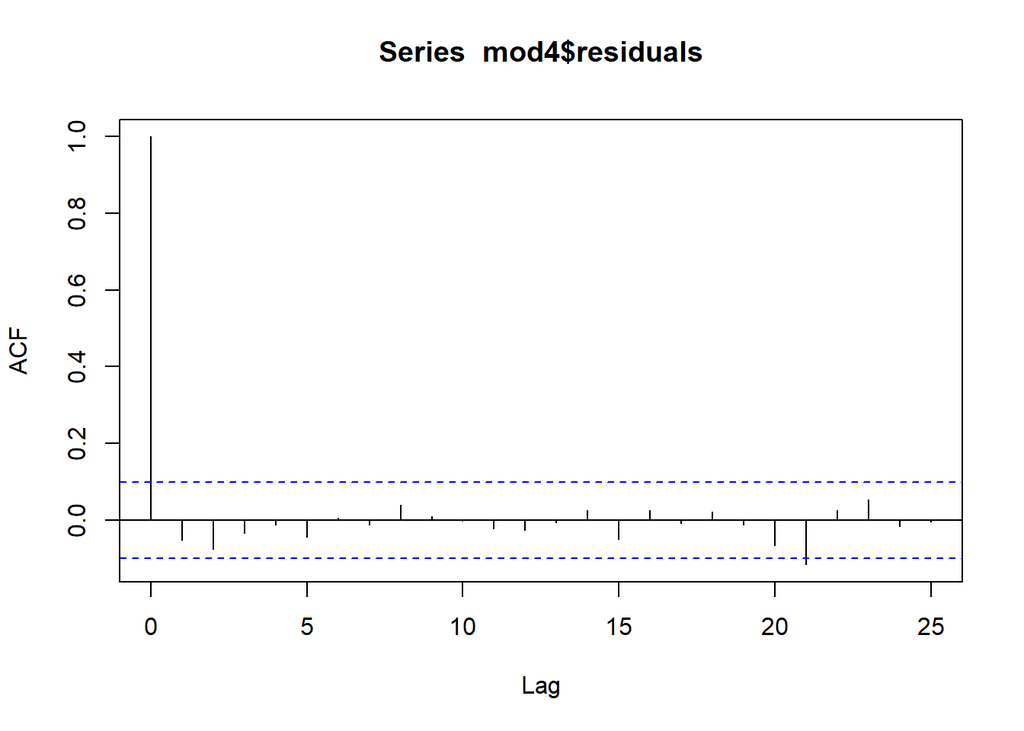

```r
acf(mod4$residuals, type="correlation")
```

```r
library(lawstat)
lmtest::dwtest(mod4)
```

```
##
##  Durbin-Watson test
##
## data:  mod4
## DW = 2.1009, p-value = 0.8385
## alternative hypothesis: true autocorrelation is greater than 0
```

The residuals are not autocorrelated, so the assumption is satisfied.

#### 5) The X variables and residuals are uncorrelated

```r
cor.test(new_PimaIndiansDiabetes2$insulin, mod4$residuals)
```

```
##
##  Pearson's product-moment correlation
##
## data:  new_PimaIndiansDiabetes2$insulin and mod4$residuals
## t = 2.0748e-17, df = 386, p-value = 1
## alternative hypothesis: true correlation is not equal to 0
## 95 percent confidence interval:
##  -0.09955811  0.09955811
## sample estimates:
##          cor
## 1.056033e-18
```

```r
cor.test(new_PimaIndiansDiabetes2$age, mod4$residuals)
```

```
##
##  Pearson's product-moment correlation
##
## data:  new_PimaIndiansDiabetes2$age and mod4$residuals
## t = -3.4404e-15, df = 386, p-value = 1
## alternative hypothesis: true correlation is not equal to 0
## 95 percent confidence interval:
##  -0.09955811  0.09955811
## sample estimates:
##           cor
## -1.751117e-16
```

This assumption is also satisfied, the regressors are exogenous.

#### 6) The number of observations must be greater than the number of predictors

Since there are 388 observations and only 3 independent variables, the assumption is satisfied according to the **one in ten rule**.

#### 7) Absence of perfect multicollinearity

```r
car::vif(mod4)
```

```
##                      GVIF Df GVIF^(1/(2*Df))
## poly(insulin, 3) 1.167172  3        1.026099
## age              1.156068  1        1.075206
## diabetes         1.230421  1        1.109244
```

The variance inflaction factors of all the variables are < 5, so there is no perfect linear relationship between the predictors and the assumption is satisfied.

# Logistic Regression

Let’s now shift the attention on the variables which can influence the probability of having the diabetes.

## Model

First of all, let’s consider the full model:

```r
# Fit the logistic regression model
logistic1 <- glm(diabetes ~., data = PimaIndiansDiabetes2,
               family = "binomial")
summary(logistic1)
```

```
##
## Call:
## glm(formula = diabetes ~ ., family = "binomial", data = PimaIndiansDiabetes2)
##
## Deviance Residuals:
##     Min       1Q   Median       3Q      Max
## -2.5810  -0.6517  -0.3709   0.6501   2.6239
##
## Coefficients:
##               Estimate Std. Error z value Pr(>|z|)
## (Intercept) -10.175488   1.230427  -8.270  < 2e-16 ***
## pregnant      0.078369   0.055037   1.424 0.154468
## glucose       0.038181   0.005812   6.569 5.06e-11 ***
## pressure      0.002545   0.011988   0.212 0.831851
## triceps       0.012683   0.017141   0.740 0.459352
## insulin      -0.000321   0.001323  -0.243 0.808284
## mass          0.060878   0.027595   2.206 0.027378 *
## pedigree      1.528786   0.447170   3.419 0.000629 ***
## age           0.030044   0.018333   1.639 0.101257
## ---
## Signif. codes:  0 '***' 0.001 '**' 0.01 '*' 0.05 '.' 0.1 ' ' 1
##
## (Dispersion parameter for binomial family taken to be 1)
##
##     Null deviance: 496.68  on 391  degrees of freedom
## Residual deviance: 348.12  on 383  degrees of freedom
## AIC: 366.12
##
## Number of Fisher Scoring iterations: 5
```

Again, let’s proceed with a backward approach, by iteratively removing the least contributive variables. The final model is the following:

```r
# Fit the logistic regression model
logistic2 <- glm(diabetes ~ glucose + mass + pedigree + age, data = PimaIndiansDiabetes2,
               family = "binomial")
summary(logistic2)
```

```
##
## Call:
## glm(formula = diabetes ~ glucose + mass + pedigree + age, family = "binomial",
##     data = PimaIndiansDiabetes2)
##
## Deviance Residuals:
##     Min       1Q   Median       3Q      Max
## -2.8790  -0.6594  -0.3805   0.6662   2.6355
##
## Coefficients:
##               Estimate Std. Error z value Pr(>|z|)
## (Intercept) -10.183058   1.098268  -9.272  < 2e-16 ***
## glucose       0.037277   0.005081   7.337 2.19e-13 ***
## mass          0.070183   0.020245   3.467 0.000527 ***
## pedigree      1.484348   0.439116   3.380 0.000724 ***
## age           0.049630   0.013379   3.709 0.000208 ***
## ---
## Signif. codes:  0 '***' 0.001 '**' 0.01 '*' 0.05 '.' 0.1 ' ' 1
##
## (Dispersion parameter for binomial family taken to be 1)
##
##     Null deviance: 496.68  on 391  degrees of freedom
## Residual deviance: 350.89  on 387  degrees of freedom
## AIC: 360.89
##
## Number of Fisher Scoring iterations: 5
```

If we want to interpret the results according to probabilities, we have to pass to the exponential transformations of the coefficients:

```r
coefs <- coef(logistic2) # if b was positive, exp(b)>1
(exp(coefs)-1)*100  # percent change in the odds for a one unit increase in the independent variable.
```

```
## (Intercept)     glucose        mass    pedigree         age
##  -99.996219    3.798019    7.270464  341.208878    5.088219
```

```r
library(pscl)
pR2(logistic2)
```

```
## fitting null model for pseudo-r2
```

```
##          llh      llhNull           G2     McFadden         r2ML         r2CU
## -175.4448121 -248.3423306  145.7950370    0.2935364    0.3105948    0.4323789
```

The McFadden Pseudo R-squared indicates an excellent model fit since it is in the range 0.2-0.4.

### Assumptions

Let’s check the assumptions of the logistic regression.

#### 1) The observations are independent of each other

This assumption is satisfied because the observations do not come from repeated measurement. Each statistical unit is a different woman.

#### 2) No high multicollinearity between the independent variables

```r
car::vif(logistic2)
```

```
##  glucose     mass pedigree      age
## 1.044599 1.012483 1.022934 1.035123
```

The variance inflaction factors are < 5 for all the independent variables, so multicollinearity is absent.

#### 3) Linear relationship between independent variables and logit

To check this assumption, first of all I compute the predicted probabilities of diabete positivity

```r
# Predict the probability (p) of diabete positivity
probabilities <- predict(logistic2, type = "response")
predicted.classes <- ifelse(probabilities > 0.5, "pos", "neg")
head(predicted.classes)
```

```
##     1     2     3     4     5     6
## "neg" "neg" "neg" "pos" "pos" "pos"
```

```r
# Select only numeric predictors
mydata <- PimaIndiansDiabetes2 %>%
  dplyr::select(glucose, mass, pedigree, age)
predictors <- colnames(mydata) # names of the predictors
# Bind the logit and tidying the data for doing the plot
mydata <- mydata %>%
  mutate(logit = log(probabilities/(1-probabilities))) %>%
  gather(key = "predictors", value = "predictor.value", -logit)
```

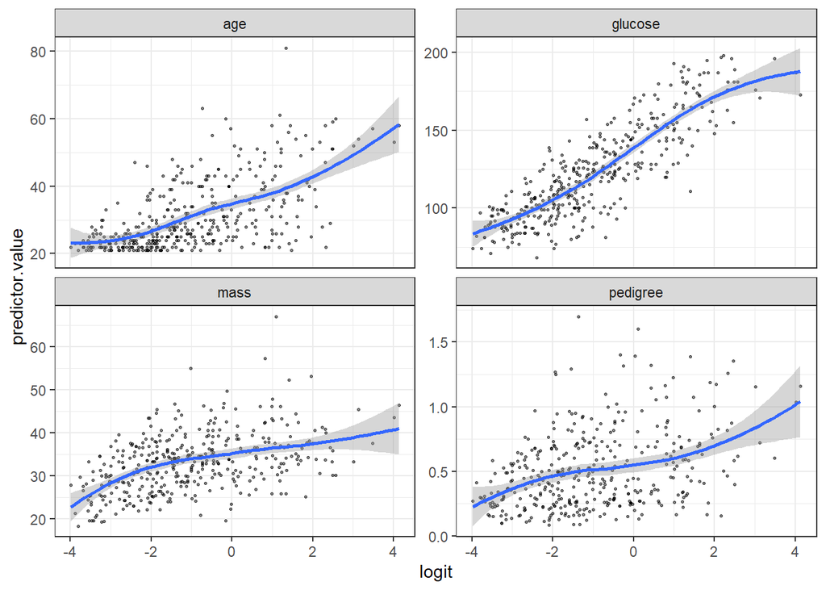

```r
ggplot(mydata, aes(logit, predictor.value))+
  geom_point(size = 0.5, alpha = 0.5) +
  geom_smooth(method = "loess") +
  theme_bw() +
  facet_wrap(~predictors, scales = "free_y")
```

The linearity assumption is more or less satisfied.

#### 4) Large sample size

This assumption is also satisfied because we have at least 10 observations per predictor.

#### Influential values

Finally, let’s check if there are some influential observations. (according to the Cook’s distance).

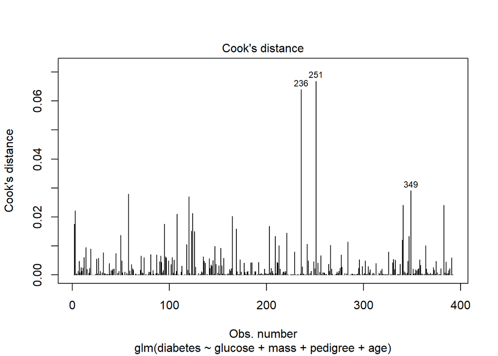

```r
plot(logistic2, which = 4, id.n = 3)
```

Not all outliers are influential observations. To check whether the data contains potential influential observations, the standardized residual error can be inspected. Data points with an absolute standardized residuals above 3 represent possible influential observations and may deserve closer attention.

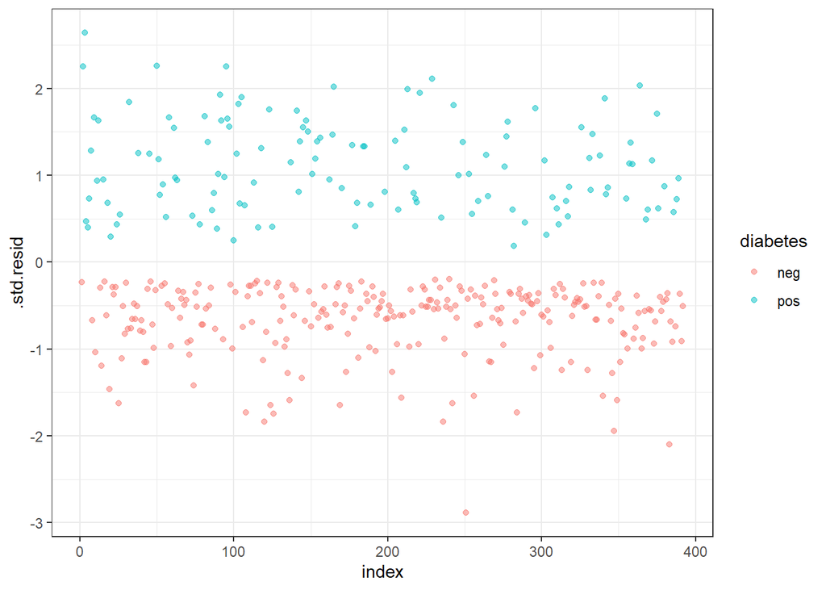

```r
# Extract model results
library(broom)
model.data <- augment(logistic2) %>%
  mutate(index = 1:n())
ggplot(model.data, aes(index, .std.resid)) +
  geom_point(aes(color = diabetes), alpha = .5) +
  theme_bw()
```

```r
model.data %>%
  filter(abs(.std.resid) > 3)
```

```
## # A tibble: 0 x 12
## # ... with 12 variables: diabetes <fct>, glucose <dbl>, mass <dbl>,
## #   pedigree <dbl>, age <dbl>, .fitted <dbl>, .resid <dbl>, .std.resid <dbl>,
## #   .hat <dbl>, .sigma <dbl>, .cooksd <dbl>, index <int>
```

There are no influential observations.

# Unsupervised classification

## Data set

For this part of the project I will consider a data set about the quality of life in different countries.

In particular, this data set contains 10 variables measured on 96 countries. The variables are:

- **country:** name of the country;
- **child_mort:** mortality rate of children under the age of five;
- **exports:** ialue of the exports (in billions);
- **health:** index that measures the extent to which people in a country are healthy and have access to the necessary services to maintain good health;
- **imports:** value of the imports (in billions);
- **income:** mean income ($);
- **inflation:** inflation rate;
- **total_fer:** fertility rate;
- **gdpp:** gross domestic product per capita ($).

Let’s explore the data set by providing a summary of the variables:

```r
library(cluster)
library(factoextra)
library(clValid)
library(writexl)
library(readxl)
country_data <- read_excel("country_data.xlsx")


print(dfSummary(country_data,
                varnumbers =  FALSE,
                valid.col = FALSE,
                graph.magnif = 0.75),
      method = 'render')
```

Data Frame Summary

country_data

**Dimensions**: 96 x 10  
**Duplicates**: 0

| **Variable** | **Stats / Values** | **Freqs (% of Valid)** | **Graph** | **Missing** |
| --- | --- | --- | --- | --- |
| country [character] | 1. Afghanistan 2. Angola 3. Australia 4. Austria 5. Bahrain 6. Belarus 7. Belgium 8. Benin 9. Bosnia and Herzegovina 10. Botswana [ 86 others ] | 1 ( 1.0% ) 1 ( 1.0% ) 1 ( 1.0% ) 1 ( 1.0% ) 1 ( 1.0% ) 1 ( 1.0% ) 1 ( 1.0% ) 1 ( 1.0% ) 1 ( 1.0% ) 1 ( 1.0% ) 86 ( 89.6% ) |  | 0 (0.0%) |
| child_mort [numeric] | Mean (sd) : 50.1 (49.3) min ≤ med ≤ max: 2.6 ≤ 53.1 ≤ 208 IQR (CV) : 84.9 (1) | 77 distinct values |  | 0 (0.0%) |
| exports [numeric] | Mean (sd) : 42.2 (32.9) min ≤ med ≤ max: 0.1 ≤ 34 ≤ 200 IQR (CV) : 29.7 (0.8) | 88 distinct values |  | 0 (0.0%) |
| health [numeric] | Mean (sd) : 7.4 (3) min ≤ med ≤ max: 1.8 ≤ 7.4 ≤ 17.9 IQR (CV) : 4.5 (0.4) | 91 distinct values |  | 0 (0.0%) |
| imports [numeric] | Mean (sd) : 47.5 (26.9) min ≤ med ≤ max: 0.1 ≤ 43.1 ≤ 174 IQR (CV) : 27.2 (0.6) | 90 distinct values |  | 0 (0.0%) |
| income [numeric] | Mean (sd) : 19797.8 (22221.6) min ≤ med ≤ max: 609 ≤ 12350 ≤ 125000 IQR (CV) : 31835 (1.1) | 90 distinct values |  | 0 (0.0%) |
| inflation [numeric] | Mean (sd) : 7.2 (12) min ≤ med ≤ max: -3.2 ≤ 3.8 ≤ 104 IQR (CV) : 7.7 (1.7) | 92 distinct values |  | 0 (0.0%) |
| life_expec [numeric] | Mean (sd) : 68.9 (10.9) min ≤ med ≤ max: 32.1 ≤ 68.9 ≤ 82.8 IQR (CV) : 20 (0.2) | 83 distinct values |  | 0 (0.0%) |
| total_fer [numeric] | Mean (sd) : 3.3 (1.8) min ≤ med ≤ max: 1.1 ≤ 2.7 ≤ 7.5 IQR (CV) : 3.4 (0.5) | 88 distinct values |  | 0 (0.0%) |
| gdpp [numeric] | Mean (sd) : 17408 (22423.5) min ≤ med ≤ max: 231 ≤ 5720 ≤ 105000 IQR (CV) : 29860 (1.3) | 94 distinct values |  | 0 (0.0%) |

Generated by summarytools 1.0.0 ([R](https://www.r-project.org/) version 4.1.1)  
2022-07-07

To perform unsupervised classification let’s normalize the variables to remove the effects of different ranges of variation.

```r
country_data <- country_data %>%
  select_if(is.numeric)
normalize <- function(x){
  return ((x-min(x))/(max(x)-min(x)))
}
country_data <- as.data.frame(lapply(country_data,normalize))
country_data1 <- read_excel("country_data.xlsx")
rownames(country_data)=country_data1$country
head(country_data)
```

```
##              child_mort    exports     health   imports      income  inflation
## Afghanistan 0.426484907 0.04948197 0.35860783 0.2577649 0.008047206 0.11807499
## Angola      0.566699124 0.31112456 0.06463642 0.2462663 0.042535232 0.23894796
## Australia   0.010710808 0.09850869 0.43008080 0.1197816 0.327925654 0.04085059
## Austria     0.008276534 0.25609457 0.57116221 0.2744378 0.342396154 0.03817385
## Bahrain     0.029211295 0.34714419 0.19639528 0.2922607 0.325513904 0.09942175
## Belarus     0.014118793 0.25659484 0.23617154 0.3704512 0.125338650 0.17086364
##             life_expec  total_fer        gdpp
## Afghanistan  0.4753452 0.73659306 0.003073428
## Angola       0.5522682 0.79022082 0.031488322
## Australia    0.9842209 0.12302839 0.493170690
## Austria      0.9546351 0.04574132 0.445446649
## Bahrain      0.8658777 0.15930599 0.195372677
## Belarus      0.7554241 0.05362776 0.055350342
```

Let’s perform internal and external validation in order to see which is the most appropriate clustering method for this set of data.

## Internal and stability validation

```r
intern <- clValid(country_data, 2:10,
                  clMethods = c("hierarchical", "kmeans", "diana", "pam"), method = "complete", metric = "euclidean",
                  validation = "internal")    # we try from 2 to 6 groups

summary(intern)  # tell us best method and number of groups
```

```
##
## Clustering Methods:
##  hierarchical kmeans diana pam
##
## Cluster sizes:
##  2 3 4 5 6 7 8 9 10
##
## Validation Measures:
##                                  2       3       4       5       6       7       8       9      10
##
## hierarchical Connectivity   0.2000  5.7369  8.6659 11.5948 14.5238 26.2798 43.1813 44.9313 52.0976
##              Dunn           0.2441  0.3007  0.3108  0.3260  0.3611  0.1631  0.1398  0.1500  0.1643
##              Silhouette     0.4978  0.4989  0.4872  0.4700  0.4518  0.3463  0.2443  0.2412  0.2528
## kmeans       Connectivity   0.2000  5.7369 12.8083 15.7373 35.2310 34.6226 40.6825 42.4325 44.1504
##              Dunn           0.2441  0.3007  0.1759  0.1845  0.1711  0.1807  0.1336  0.1347  0.1571
##              Silhouette     0.4978  0.4989  0.4413  0.4263  0.3194  0.2879  0.2923  0.2892  0.2897
## diana        Connectivity   0.2000  5.7369  8.6659 11.5948 14.5238 17.4528 31.4357 33.1857 36.7198
##              Dunn           0.2441  0.3007  0.3108  0.3260  0.3611  0.3873  0.1974  0.1991  0.2020
##              Silhouette     0.4978  0.4989  0.4872  0.4700  0.4518  0.3871  0.3017  0.2974  0.2870
## pam          Connectivity   0.2000 22.0500 33.7607 38.4437 49.9706 66.9651 72.0421 73.0921 88.2933
##              Dunn           0.2441  0.1140  0.0823  0.0997  0.0755  0.0743  0.0743  0.0743  0.0743
##              Silhouette     0.4978  0.3577  0.2448  0.2621  0.2353  0.2217  0.2223  0.2281  0.1987
##
## Optimal Scores:
##
##              Score  Method       Clusters
## Connectivity 0.2000 hierarchical 2
## Dunn         0.3873 diana        7
## Silhouette   0.4989 hierarchical 3
```

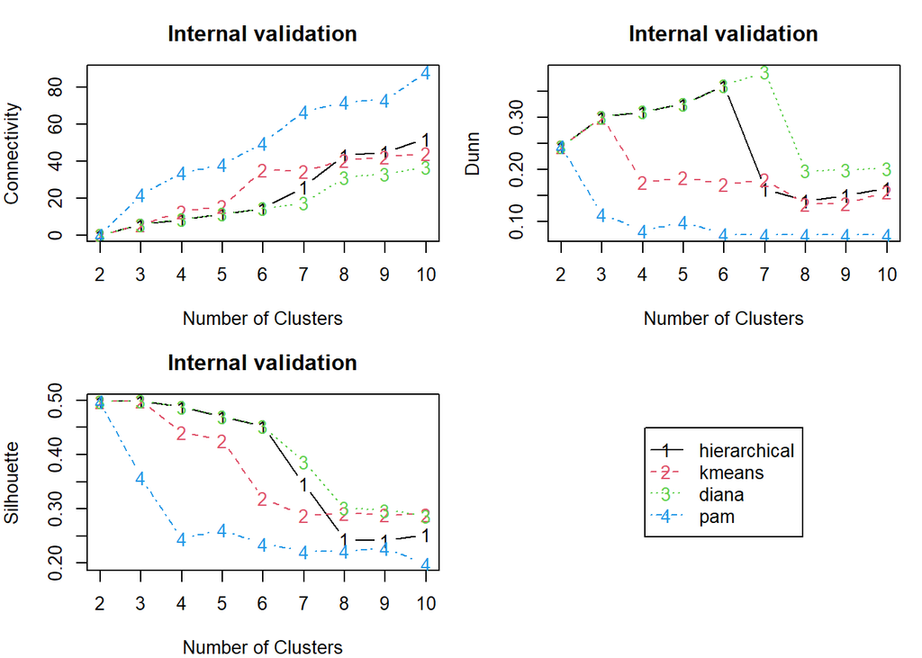

```r
op <- par(no.readonly=TRUE)
par(mfrow=c(2,2),mar=c(4,4,3,1))
plot(intern, legend=FALSE)
plot(nClusters(intern),measures(intern,"Dunn")[,,1],type="n",axes=F,
     xlab="",ylab="")
legend("center", clusterMethods(intern), col=1:9, lty=1:9, pch=paste(1:9))
```

```r
par(op)
```

```r
stab <- clValid(country_data, 2:10, clMethods=c("hierarchical","kmeans","diana","pam"), metric = "euclidean", method = "complete",
                validation="stability")

summary(stab)                # tell us best method and number of groups
```

```
##
## Clustering Methods:
##  hierarchical kmeans diana pam
##
## Cluster sizes:
##  2 3 4 5 6 7 8 9 10
##
## Validation Measures:
##                        2      3      4      5      6      7      8      9     10
##
## hierarchical APN  0.0000 0.0067 0.0129 0.0129 0.0477 0.1022 0.1183 0.1499 0.1408
##              AD   0.4990 0.4638 0.4543 0.4388 0.4264 0.4135 0.3955 0.3804 0.3643
##              ADM  0.0000 0.0071 0.0200 0.0190 0.0324 0.0627 0.0979 0.0940 0.0878
##              FOM  0.1331 0.1250 0.1251 0.1248 0.1244 0.1246 0.1252 0.1198 0.1174
## kmeans       APN  0.0000 0.0205 0.0691 0.1091 0.2242 0.2429 0.0818 0.1079 0.1182
##              AD   0.4990 0.4689 0.4538 0.4396 0.4310 0.3995 0.3611 0.3486 0.3367
##              ADM  0.0000 0.0187 0.0485 0.0601 0.1280 0.1453 0.0824 0.0807 0.0793
##              FOM  0.1331 0.1320 0.1302 0.1299 0.1251 0.1215 0.1212 0.1177 0.1166
## diana        APN  0.0000 0.0076 0.0144 0.0144 0.0471 0.1007 0.1466 0.2855 0.2342
##              AD   0.4990 0.4657 0.4563 0.4408 0.4287 0.4192 0.4063 0.3972 0.3603
##              ADM  0.0000 0.0094 0.0248 0.0233 0.0358 0.0543 0.0934 0.1407 0.1196
##              FOM  0.1331 0.1279 0.1285 0.1282 0.1264 0.1239 0.1219 0.1191 0.1180
## pam          APN  0.0068 0.1257 0.0954 0.1085 0.1996 0.2063 0.2208 0.2260 0.2249
##              AD   0.5015 0.4804 0.4290 0.3995 0.3925 0.3769 0.3695 0.3575 0.3478
##              ADM  0.0071 0.0922 0.0524 0.0553 0.1036 0.1085 0.1215 0.1209 0.1271
##              FOM  0.1358 0.1339 0.1270 0.1218 0.1211 0.1185 0.1190 0.1166 0.1127
##
## Optimal Scores:
##
##     Score  Method       Clusters
## APN 0.0000 hierarchical 2
## AD  0.3367 kmeans       10
## ADM 0.0000 hierarchical 2
## FOM 0.1127 pam          10
```

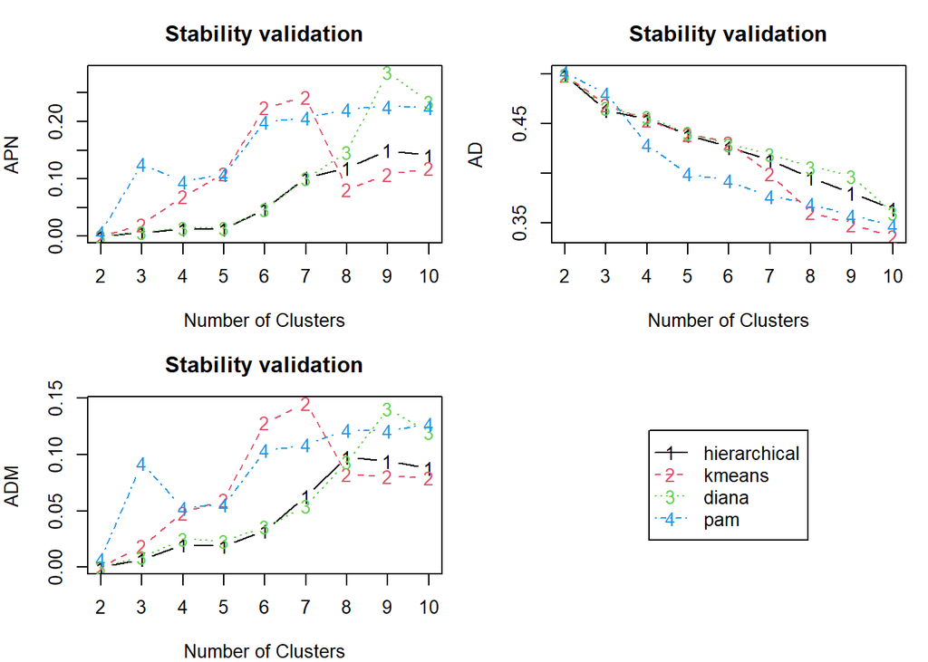

```r
# optimalScores(stab)

# we omit  FOM measure that is very similar to the AD measure,

par(mfrow=c(2,2),mar=c(4,4,3,1))
plot(stab, measure=c("APN","AD","ADM"),legend=FALSE)
plot(nClusters(stab),measures(stab,"APN")[,,1],type="n",axes=F,
     xlab="",ylab="")
legend("center", clusterMethods(stab), col=1:9, lty=1:9, pch=paste(1:9))
```

```r
par(op)
```

## Agglomerative hierarchical clustering

From the results it’s clear that the best approach is to use agglomerative hierarchical clustering with 2 clusters.

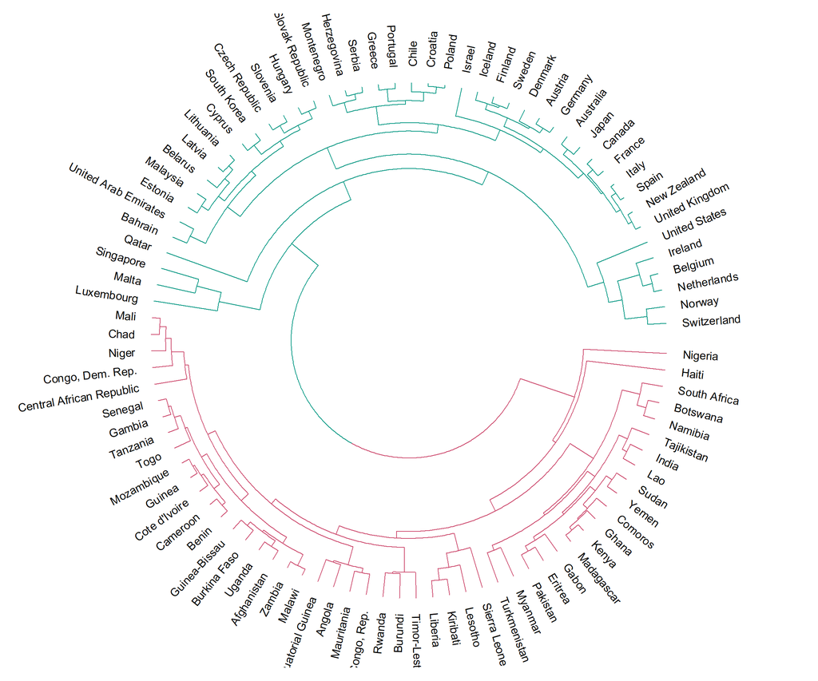

```r
# euclidean - complete linkage
dd=dist(country_data, method = "euclidean") # 2 variables because I want to plot the groups
library(dendextend)
clusters = hclust(dd,method = "complete")
cut = cutree(clusters, 2)
dend <- as.dendrogram(clusters)
dend <- color_branches(dend, k=2)
circlize_dendrogram(dend, labels = TRUE)
```

To interpret the results, let’s perform a principal component analysis.

### Principal Component Analysis

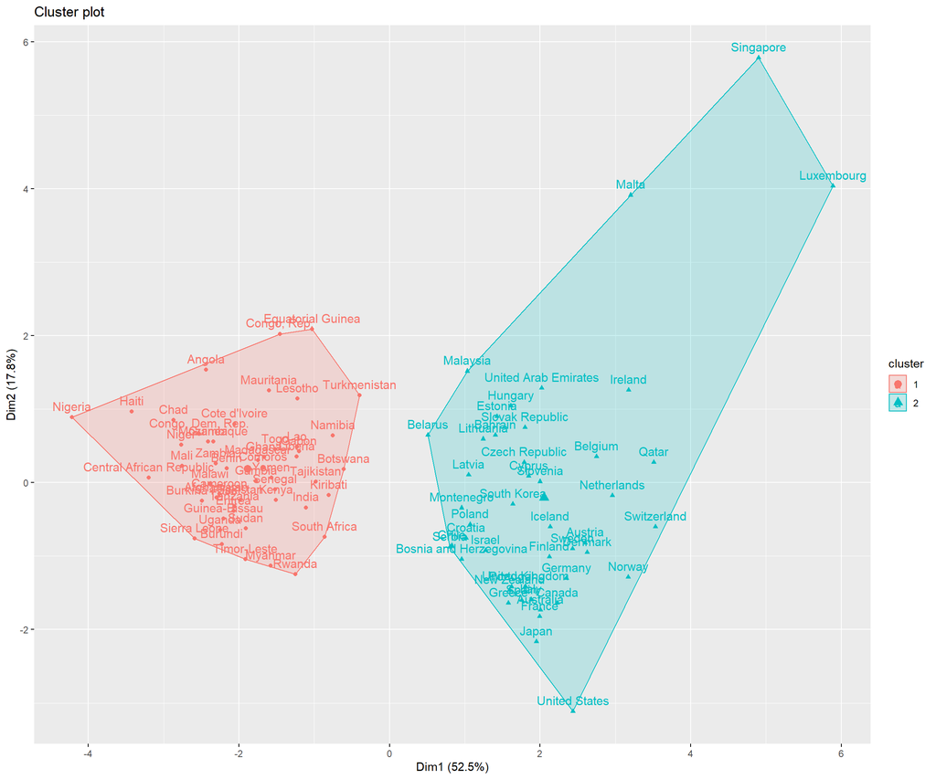

```r
library(factoextra)
fviz_cluster(list(data = country_data, cluster = cut))
```

Let’s see which are the variables that influence the principal components

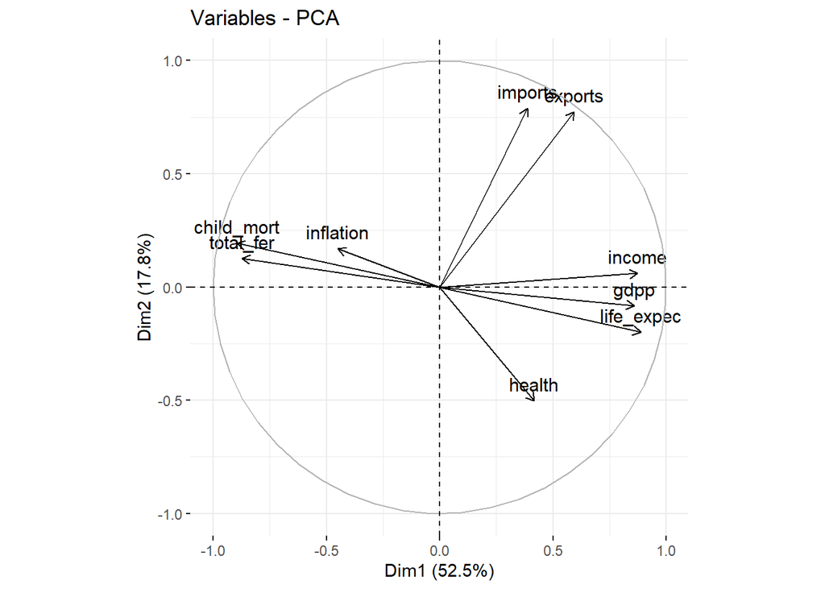

```r
library(gridExtra)
res.pca <- prcomp(country_data, scale = TRUE)
fviz_pca_var(res.pca, scale = TRUE)
```

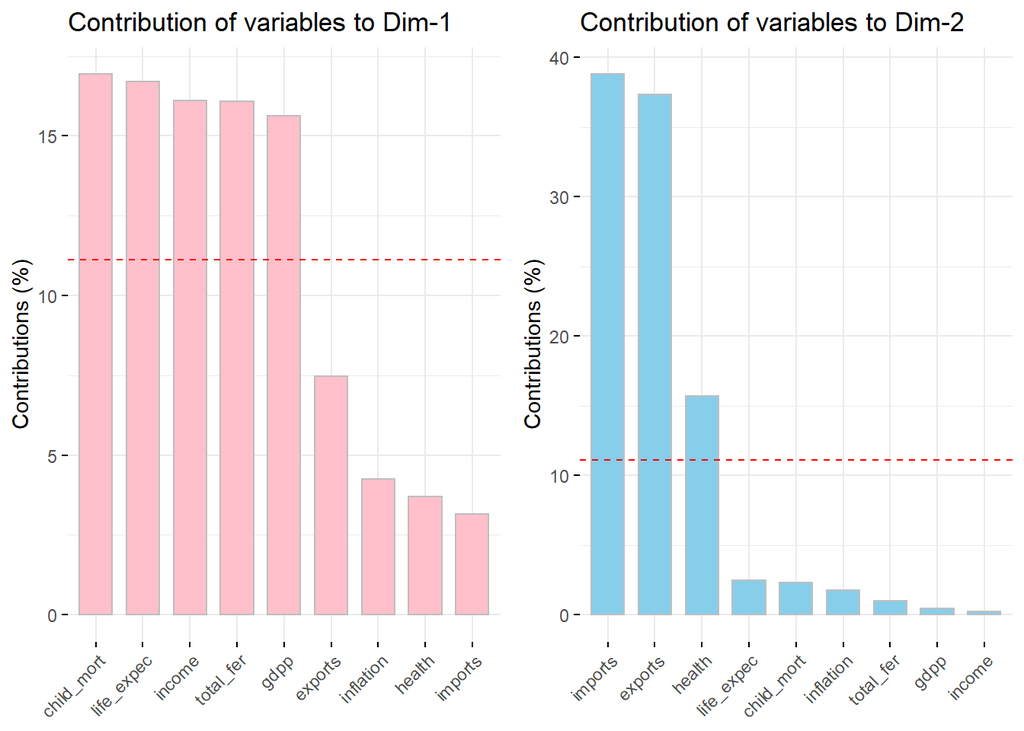

```r
p1 <- fviz_contrib(res.pca, choice="var", axes=1, fill="pink", color="grey", top=10)
p2 <- fviz_contrib(res.pca, choice="var", axes=2, fill="skyblue", color="grey", top=10)
grid.arrange(p1,p2,ncol=2)
```

The first principal component is determined by variables related to the quality of life (life_expect, child_mort, total_fert, income) while the second principal component is determined more by economic variables (imports and exports). So we can easily understand that the blue cluster is made by advanced economies and “civilized” countries (incomes, life expectancy and gdp above the average, child mortality below the average), while the red cluster is made by poor countries (income, gpd and life expectancy below the average, child mortality above the average), in which there are wars and in which the quality of life is not high.

# Supervised classification

## Data set

In this last section of the project, I will consider a data set about the characteristics of two types of wines produced in Portugal.

In particular, this data set contains 13 variables measured on 6463 wines. The variables are:

- **type:** type of the wine (red or white);
- **fixed_acidity:** difference between total acidity and volatile acidity (mg/L);
- **volatile_acidity:** steam distillable acids present in wine (mg/L);
- **citric_acid:** quantity of acidification to boost the wine’s total acidity (g);
- **residual_sugar:** sugar left unfermented in a finished wine (g/L);
- **chlorides:** indicative of the presence of sodium chloride 5 Sodium chloride adds to the saltiness of a wine, which can contribute to or detract from the overall taste and quality of the wine (mg/L);
- **free_sulfur_dioxide:** gives anti-oxidative and anti-microbial properties to wine (ppm);
- **total_sulfur_dioxide:** portion of SO2 that is free in the wine plus the portion that is bound to other chemicals in the wine such as aldehydes, pigments, or sugars (mg/L);
- **density:** ratio between mass and volume (g/cm3);
- **pH:** measure of the acidity of wine;
- **suplhates:** give antioxidant and antibacterial action to wine (mg/L);
- **alcohol:** percentage of alcohol present;
- **quality:** quality of the wine (1=poor, 10=excellent)

Let’s explore the data set by providing a summary of the variables:

```r
library(readxl)
winequalityN <- read_excel("winequalityN.xlsx")
winequalityN$type <- as.factor(winequalityN$type)
winequalityN <- as.data.frame(winequalityN)
print(dfSummary(winequalityN,
                varnumbers =  FALSE,
                valid.col = FALSE,
                graph.magnif = 0.75),
      method = 'render')
```

Data Frame Summary

winequalityN

**Dimensions**: 6463 x 13  
**Duplicates**: 1168

| **Variable** | **Stats / Values** | **Freqs (% of Valid)** | **Graph** | **Missing** |
| --- | --- | --- | --- | --- |
| type [factor] | 1. red 2. white | 1593 ( 24.6% ) 4870 ( 75.4% ) |  | 0 (0.0%) |
| fixed_acidity [numeric] | Mean (sd) : 7.2 (1.3) min ≤ med ≤ max: 3.8 ≤ 7 ≤ 15.9 IQR (CV) : 1.3 (0.2) | 106 distinct values |  | 0 (0.0%) |
| volatile_acidity [numeric] | Mean (sd) : 0.3 (0.2) min ≤ med ≤ max: 0.1 ≤ 0.3 ≤ 1.6 IQR (CV) : 0.2 (0.5) | 187 distinct values |  | 0 (0.0%) |
| citric_acid [numeric] | Mean (sd) : 0.3 (0.1) min ≤ med ≤ max: 0 ≤ 0.3 ≤ 1.7 IQR (CV) : 0.1 (0.5) | 89 distinct values |  | 0 (0.0%) |
| residual_sugar [numeric] | Mean (sd) : 5.4 (4.8) min ≤ med ≤ max: 0.6 ≤ 3 ≤ 65.8 IQR (CV) : 6.3 (0.9) | 315 distinct values |  | 0 (0.0%) |
| chlorides [numeric] | Mean (sd) : 0.1 (0) min ≤ med ≤ max: 0 ≤ 0 ≤ 0.6 IQR (CV) : 0 (0.6) | 214 distinct values |  | 0 (0.0%) |
| free_sulfur_dioxide [numeric] | Mean (sd) : 30.5 (17.8) min ≤ med ≤ max: 1 ≤ 29 ≤ 289 IQR (CV) : 24 (0.6) | 135 distinct values |  | 0 (0.0%) |
| total_sulfur_dioxide [numeric] | Mean (sd) : 115.7 (56.5) min ≤ med ≤ max: 6 ≤ 118 ≤ 440 IQR (CV) : 79 (0.5) | 276 distinct values |  | 0 (0.0%) |
| density [numeric] | Mean (sd) : 1 (0) min ≤ med ≤ max: 1 ≤ 1 ≤ 1 IQR (CV) : 0 (0) | 996 distinct values |  | 0 (0.0%) |
| pH [numeric] | Mean (sd) : 3.2 (0.2) min ≤ med ≤ max: 2.7 ≤ 3.2 ≤ 4 IQR (CV) : 0.2 (0) | 108 distinct values |  | 0 (0.0%) |
| sulphates [numeric] | Mean (sd) : 0.5 (0.1) min ≤ med ≤ max: 0.2 ≤ 0.5 ≤ 2 IQR (CV) : 0.2 (0.3) | 111 distinct values |  | 0 (0.0%) |
| alcohol [numeric] | Mean (sd) : 10.5 (1.2) min ≤ med ≤ max: 8 ≤ 10.3 ≤ 14.9 IQR (CV) : 1.8 (0.1) | 111 distinct values |  | 0 (0.0%) |
| quality [numeric] | Mean (sd) : 5.8 (0.9) min ≤ med ≤ max: 3 ≤ 6 ≤ 9 IQR (CV) : 1 (0.2) | 3 : 30 ( 0.5% ) 4 : 214 ( 3.3% ) 5 : 2128 ( 32.9% ) 6 : 2820 ( 43.6% ) 7 : 1074 ( 16.6% ) 8 : 192 ( 3.0% ) 9 : 5 ( 0.1% ) |  | 0 (0.0%) |

Generated by summarytools 1.0.0 ([R](https://www.r-project.org/) version 4.1.1)  
2022-07-07

## K-Nearest Neighbors

Let’s perform classification using the k-nearest neighbors algorithm. In this case k = 7.

```r
library(class)
random<- sample(rep(1:6463)) # randomly generate numbers from 1 to 150
winequalityN<- winequalityN[random,] # randomize "winequalityN"
normalize <- function(x){
  return ((x-min(x))/(max(x)-min(x)))
}
winequalityN.new<- as.data.frame(lapply(winequalityN[,c(2:13)],normalize))

winequalityN.train<- winequalityN.new[1:4308,]
winequalityN.train.label<- winequalityN[1:4308,1]
winequalityN.test<- winequalityN.new[4309:6463,]
winequalityN.test.label<- winequalityN[4309:6463,1]
```

```r
set.seed(2)
predict <- knn(train=winequalityN.train, test=winequalityN.test, cl=winequalityN.train.label, k=7)
table <- table(winequalityN.test.label, predict)
table
```

```
##                        predict
## winequalityN.test.label  red white
##                   red    518     9
##                   white    9  1619
```

Choosing 7 neighbors, only 18 wines out of 2155 were not classified in the correct group, so the misclassification error rate is very low. In particular, let’s see its plot in function of k (the number of neighbors):

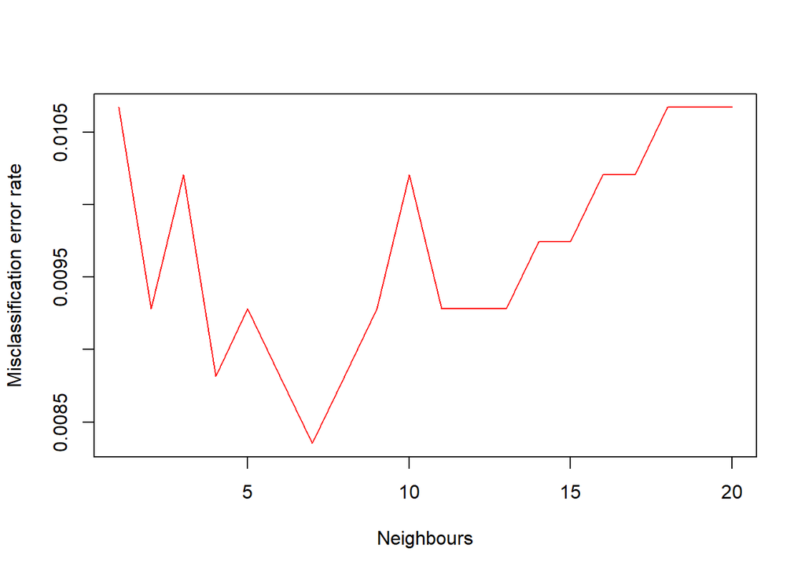

```r
err=length(winequalityN.test.label)-sum(winequalityN.test.label==predict)
error_rate=err/length(predict)
res=rep(NA,20)
for(i in 1:20){mod=knn(train=winequalityN.train, test=winequalityN.test, cl=winequalityN.train.label, k=i)
          acc=sum(winequalityN.test.label==mod)
          res[i]=1-acc/length(mod)}
plot(1:20,res,type="l",col="red", xlab="Neighbours", ylab="Misclassification error rate")
```

Since we are dealing with a binary classifier, we can also plot the ROC curve and talk about sensityivity and specifity.

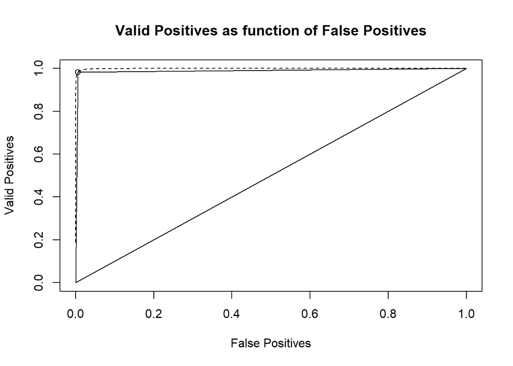

```
## Decision Theory and Area under the Curve
##
## The original data implied the following 2 x 2 table
##                        predict
## winequalityN.test.label Predicted.Pos Predicted.Neg
##                True.Pos        0.2404        0.0042
##                True.Neg        0.0042        0.7513
##
## Conditional probabilities of
##                        predict
## winequalityN.test.label Predicted.Pos Predicted.Neg
##                True.Pos        0.9829        0.0171
##                True.Neg        0.0055        0.9945
##
## Accuracy =  0.99  Sensitivity =  0.98   Specificity =  0.99
## with Area Under the Curve =  1
## d.prime =  4.66  Criterion =  2.54  Beta =  0.32
## Observed Phi correlation =  0.98
## Inferred latent (tetrachoric) correlation  =  1
```

```r
library(psych)
psych::AUC(table, plot = "a")
```

In this case, sensitivity is the proportion of actually red wines classified as red wines (actual positive classified as positive) while specifity is the proportion of actually white wines classified as white wines. They are both very high.

This also proves that the classifier is almost perfect because the area under the curve is almost 1.